# 432 Class 17

Thomas E. Love, Ph.D.

2024-03-19

## Today’s Topic

**Regression Models for Ordered Multi-Categorical Outcomes**

- Applying to Graduate School: A First Example
- Proportional Odds Logistic Regression Models
  - Using `polr` and then Using `lrm`
- Understanding and Interpreting the Model
- Testing the Proportional Odds Assumption
- Picturing the Model Fit

Chapter 27 of the Course Notes describes this material.

## Setup

```r
knitr::opts_chunk$set(comment=NA)
options(width = 80)

library(janitor)
library(broom)
library(gt)
library(GGally)    ## scatterplot matrix
library(scales)    ## adjust label formatting within ggplot2
library(MASS)      ## fitting polr models
library(nnet)      ## fitting multinomial models
library(conflicted)
library(rms)
library(tidyverse)

conflicts_prefer(dplyr::filter, dplyr::select, dplyr::summarize)

theme_set(theme_bw())
```

# Applying to Graduate School

## The `gradschool` data and my **Source**

The **gradschool** example is adapted from a site at UCLA<sup>1</sup>.

- There, they look at 400 students.
- I simulated a new data set containing 530 college juniors.

Each subject is asked “Are you unlikely, somewhat likely, or very likely to apply to graduate school?” This is our outcome.

- No reason to think that the “distances” between these categories are equal.
[^1]: http://stats.idre.ucla.edu/r/dae/ordinal-logistic-regression/

## The `gradschool` variables

| Variable | Description |
| --- | --- |
| `student` | subject identifying code (A001 - A530) |
| `apply` | 3-level ordered outcome: “unlikely”, “somewhat likely” and “very likely” to apply |
| `pared` | 1 = at least one parent has a graduate degree, else 0 |
| `public` | 1 = undergraduate institution is public, else 0 |
| `gpa` | student’s undergraduate grade point average (max 4.00) |

## Ingesting the Data

```r
gradschool <-
  read_csv("c17/data/gradschool.csv", show_col_types = FALSE) |>
  type.convert(as.is = FALSE) |> clean_names() |>
  mutate(student = as.character(student))

gradschool
```

```
# A tibble: 530 × 5
   student apply           pared public   gpa
   <chr>   <fct>           <int>  <int> <dbl>
 1 A001    very likely         0      0  3.41
 2 A002    unlikely            0      0  2.38
 3 A003    somewhat likely     0      0  3.35
 4 A004    unlikely            0      1  3.45
 5 A005    unlikely            1      1  3.27
 6 A006    somewhat likely     1      0  3.41
 7 A007    somewhat likely     0      0  2.83
 8 A008    unlikely            0      0  3.64
 9 A009    unlikely            0      0  2.52
10 A010    unlikely            0      0  2.36
# ℹ 520 more rows
```

## Our outcome as an *ordered* factor

```r
gradschool <- gradschool |>
    mutate(apply = fct_relevel(apply, "unlikely",
                        "somewhat likely", "very likely"),
           apply = factor(apply, ordered = TRUE))

is.ordered(gradschool$apply)
```

```
[1] TRUE
```

```r
glimpse(gradschool)
```

```
Rows: 530
Columns: 5
$ student <chr> "A001", "A002", "A003", "A004", "A005", "A006", "A007", "A008"…
$ apply   <ord> very likely, unlikely, somewhat likely, unlikely, unlikely, so…
$ pared   <int> 0, 0, 0, 0, 1, 1, 0, 0, 0, 0, 0, 0, 1, 0, 0, 1, 1, 0, 0, 0, 0,…
$ public  <int> 0, 0, 0, 1, 1, 0, 0, 0, 0, 0, 0, 0, 0, 0, 0, 0, 0, 0, 0, 0, 0,…
$ gpa     <dbl> 3.41, 2.38, 3.35, 3.45, 3.27, 3.41, 2.83, 3.64, 2.52, 2.36, 2.…
```

## Describing the `gradschool` data

```r
describe(gradschool) ## from Hmisc
```

```
gradschool

 5  Variables      530  Observations
--------------------------------------------------------------------------------
student
       n  missing distinct
     530        0      530

lowest : A001 A002 A003 A004 A005, highest: A526 A527 A528 A529 A530
--------------------------------------------------------------------------------
apply
       n  missing distinct
     530        0        3

Value             unlikely somewhat likely     very likely
Frequency              303             172              55
Proportion           0.572           0.325           0.104
--------------------------------------------------------------------------------
pared
       n  missing distinct     Info      Sum     Mean      Gmd
     530        0        2     0.47      103   0.1943   0.3137

--------------------------------------------------------------------------------
public
       n  missing distinct     Info      Sum     Mean      Gmd
     530        0        2    0.555      130   0.2453   0.3709

--------------------------------------------------------------------------------
gpa
       n  missing distinct     Info     Mean      Gmd      .05      .10
     530        0      186        1    3.015   0.5919    2.104    2.279
     .25      .50      .75      .90      .95
   2.610    3.080    3.440    3.660    3.760

lowest : 1.9  1.91 1.92 1.93 1.94, highest: 3.95 3.97 3.98 3.99 4
--------------------------------------------------------------------------------
```

## Scatterplot Matrix for `gradschool`

```r
ggpairs(gradschool |> select(gpa, pared, public, apply)) ## outcome last
```

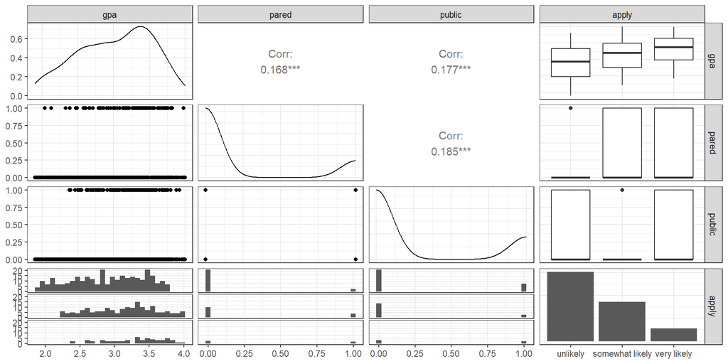

## Bar Chart of `apply` classifications with %s

```r
ggplot(gradschool, aes(x = apply, fill = apply)) +
    geom_bar(aes(y =
        (after_stat(count)/sum(after_stat(count))))) +
    geom_text(aes(y =
        (after_stat(count))/sum(after_stat(count)),
          label = scales::percent((after_stat(count)) /
                            sum(after_stat(count)))),
              stat = "count", vjust = 1.5,
              color = "white", size = 5) +
    scale_y_continuous(labels = scales::percent) +
    scale_fill_brewer(palette = "Set1") +
    guides(fill = "none") +
    labs(y = "Percentage")
```

## Bar Chart of `apply` classifications with %s

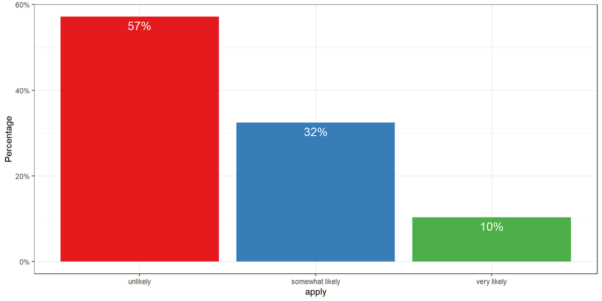

## Data (besides `gpa`) as Cross-Tabulation

```r
ftable(xtabs(~ public + apply + pared, data = gradschool))
```

```
                       pared   0   1
public apply
0      unlikely              206  17
       somewhat likely       111  32
       very likely            22  12
1      unlikely               62  18
       somewhat likely        15  14
       very likely            11  10
```

## `apply` percentages by `public`, `pared`

```r
ggplot(gradschool, aes(x = apply, fill = apply)) +
    geom_bar() +
    scale_fill_brewer(palette = "Set1") +
    guides(fill = "none") +
    facet_grid(pared ~ public, labeller = "label_both")
```

## `apply` percentages by `public`, `pared`

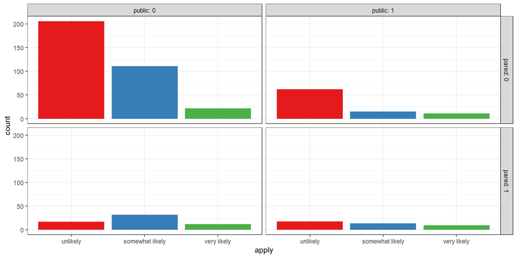

## Breakdown of `gpa` by `apply`

```r
ggplot(gradschool, aes(x = apply, y = gpa, fill = apply)) +
    geom_violin(trim = TRUE) +
    geom_boxplot(col = "white", width = 0.2) +
    scale_fill_brewer(palette = "Set1") +
    guides(fill = "none")
```

## Breakdown of `gpa` by `apply`

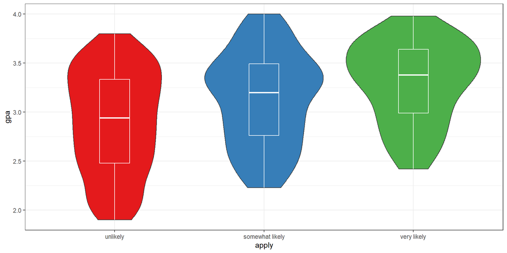

## `gpa` by three other variables

```r
ggplot(gradschool, aes(x = apply, y = gpa)) +
    geom_boxplot(aes(fill = apply), size = .75) +
    geom_jitter(alpha = .25) +
    facet_grid(pared ~ public, margins = TRUE,
               labeller = "label_both") +
    scale_fill_brewer(palette = "Set1") +
    guides(fill = "none") +
    theme(axis.text.x =
            element_text(angle = 45, hjust = 1, vjust = 1))
```

## `gpa` by three other variables

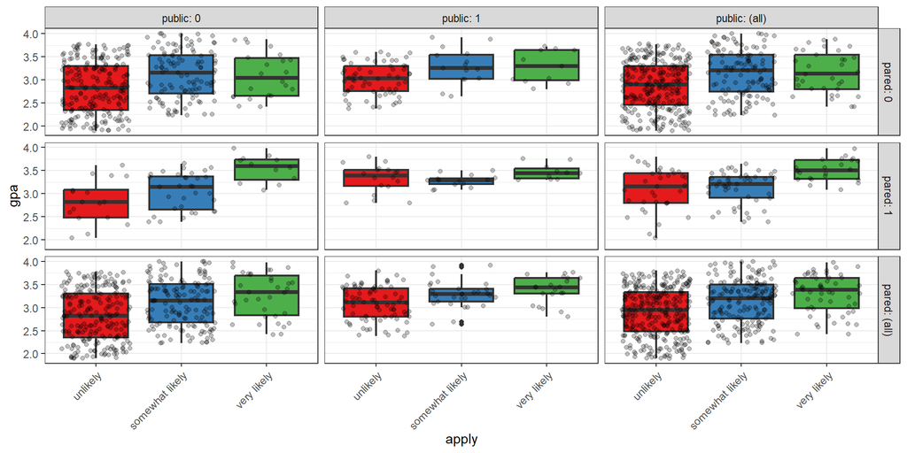

# Proportional Odds Logit Model via `polr`

## Fitting the POLR model

We use the `polr` function from the `MASS` package:

```r
mod_p1 <- polr(apply ~ pared + public + gpa,
          data = gradschool, Hess=TRUE)
```

The `polr` name comes from proportional odds logistic regression, highlighting a key assumption of this model.

- We specify `Hess=TRUE` to have the model return the observed information matrix from optimization (called the Hessian) which is used to get appropriate standard errors.

## `mod_p1` Predicted Probabilities

The model’s predicted probabilities are usually the best way to understand what it does.

For example, we vary `gpa` for each level of `pared` and `public` and calculate the model’s estimated probability of being in each category of `apply`.

First, create a new tibble of values to use for prediction.

```r
newdat <- tibble(
  pared = rep(0:1, 200),
  public = rep(0:1, each = 200),
  gpa = rep(seq(from = 1.9, to = 4, length.out = 100), 4))
```

## `mod_p1` Predicted Probabilities

Now, make predictions using model `mod_p1`:

```r
newdat_p1 <- cbind(newdat,
                 predict(mod_p1, newdat, type = "probs"))
head(newdat_p1) |> gt() |> fmt_number(decimals = 3) |>
  tab_options(table.font.size = 20)
```

| pared | public | gpa | unlikely | somewhat likely | very likely |
| --- | --- | --- | --- | --- | --- |
| 0.000 | 0.000 | 1.900 | 0.846 | 0.132 | 0.022 |
| 1.000 | 0.000 | 1.921 | 0.629 | 0.302 | 0.069 |
| 0.000 | 0.000 | 1.942 | 0.840 | 0.137 | 0.024 |
| 1.000 | 0.000 | 1.964 | 0.617 | 0.310 | 0.073 |
| 0.000 | 0.000 | 1.985 | 0.833 | 0.142 | 0.025 |
| 1.000 | 0.000 | 2.006 | 0.606 | 0.318 | 0.076 |

## Reshape data

Now, we reshape the data with `pivot_longer`:

```r
newdat_long <-
  pivot_longer(newdat_p1,
               cols = c("unlikely":"very likely"),
               names_to = "level",
               values_to = "probability") |>
  mutate(level = fct_relevel(level, "unlikely",
                             "somewhat likely"))
```

Result on next slide…

## The `newdat_long` data

```r
newdat_long
```

```
# A tibble: 1,200 × 5
   pared public   gpa level           probability
   <int>  <int> <dbl> <fct>                 <dbl>
 1     0      0  1.9  unlikely             0.846
 2     0      0  1.9  somewhat likely      0.132
 3     0      0  1.9  very likely          0.0225
 4     1      0  1.92 unlikely             0.629
 5     1      0  1.92 somewhat likely      0.302
 6     1      0  1.92 very likely          0.0694
 7     0      0  1.94 unlikely             0.840
 8     0      0  1.94 somewhat likely      0.137
 9     0      0  1.94 very likely          0.0236
10     1      0  1.96 unlikely             0.617
# ℹ 1,190 more rows
```

## `mod_p1` Predictions

```r
ggplot(newdat_long, aes(x = gpa, y = probability,
                        color = level)) +
    geom_line(size = 1.5) +
    scale_color_brewer(palette = "Set1") +
    facet_grid(pared ~ public, labeller="label_both")
```

## `mod_p1` Predictions

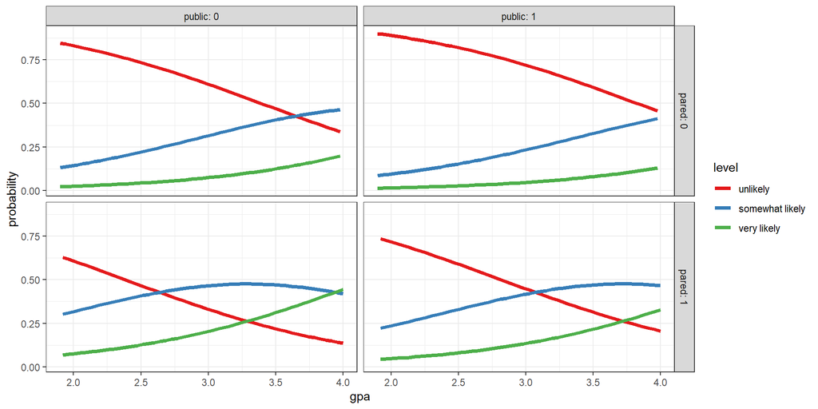

## Predicted vs. Observed Classifications

Predictions in the rows, Observed in the columns

```r
addmargins(table(predict(mod_p1), gradschool$apply))
```

```
                  unlikely somewhat likely very likely Sum
  unlikely             264             112          29 405
  somewhat likely       39              60          25 124
  very likely            0               0           1   1
  Sum                  303             172          55 530
```

We only predict one subject to be in the “very likely” group by modal prediction.

## Proportional Odds Logistic Model

Our outcome `apply` has three levels, so `mod_p1` includes two equations:

- one estimating the log odds that `apply` will be less than or equal to 1 (`apply` = “unlikely”)
- one estimating the log odds that `apply` $\leq$ 2 (`apply` = “unlikely” or “somewhat likely”)

That’s all we need, since Pr(`apply` $\leq$ 3) = 1, because “very likely” is the highest `apply` category.

## Parameters of the POLR Model

- The parameters to be fit include two intercepts:
  - $\zeta_1$ will be the `unlikely|somewhat likely` parameter
  - $\zeta_2$ will be the `somewhat likely|very likely` parameter (*read these as zeta-one, and zeta-two*)

We’ll have a total of five free parameters when we add in the slopes ($\beta$) for `pared`, `public` and `gpa`.

- The two logistic equations that will be fit differ only in their intercepts.

## `summary(mod_p1)`

```r
summary(mod_p1)
```

```
Call:
polr(formula = apply ~ pared + public + gpa, data = gradschool,
    Hess = TRUE)

Coefficients:
         Value Std. Error t value
pared   1.1525     0.2184   5.276
public -0.4949     0.2195  -2.254
gpa     1.1416     0.1850   6.171

Intercepts:
                            Value   Std. Error t value
unlikely|somewhat likely     3.8727  0.5721     6.7692
somewhat likely|very likely  5.9413  0.6063     9.7993

Residual Deviance: 900.9629
AIC: 910.9629
```

## Understanding the Model

$$logit[Pr(apply \leq 1)] = \zeta_1 - \beta_1 pared - \beta_2 public - \beta_3 gpa$$

$$logit[Pr(apply \leq 2)] = \zeta_2 - \beta_1 pared - \beta_2 public - \beta_3 gpa$$

in general. In our setting, we have …

## The `mod_p1` equations…

$$logit[Pr(apply \leq unlikely)] =$$

$$3.87 - 1.15 pared - (-0.49) public - 1.14 gpa$$

and

$$logit[Pr(apply \leq somewhat)] =$$

$$5.94 - 1.15 pared - (-0.49) public - 1.14 gpa$$

## `confint(mod_p1)`

Confidence intervals for the slope coefficients on the log odds scale can be estimated in the usual way.

```r
confint(mod_p1)
```

```
            2.5 %      97.5 %
pared   0.7257019  1.58305735
public -0.9320573 -0.07029727
gpa     0.7837559  1.50974002
```

These CIs describe results in units of ordered log odds.

- For example, for a one unit increase in `gpa`, we expect a 1.14 increase in the expected value of `apply` (95% CI 0.78, 1.51) in the log odds scale, holding `pared` and `public` constant.
- This would be more straightforward if we exponentiated.

## Exponentiating the Coefficients

```r
exp(coef(mod_p1))
```

```
    pared    public       gpa
3.1660446 0.6096623 3.1318247
```

```r
exp(confint(mod_p1))
```

```
           2.5 %    97.5 %
pared  2.0661808 4.8698218
public 0.3937428 0.9321167
gpa    2.1896811 4.5255541
```

## Interpreting the Coefficients

| Variable | Estimate | 95% CI |
| --- | --- | --- |
| `gpa` | 3.13 | (2.19, 4.53) |
| `public` | 0.61 | (0.39, 0.93) |
| `pared` | 3.17 | (2.07, 4.87) |

- When a student’s `gpa` increases by 1 unit, the odds of moving from “unlikely” applying to “somewhat likely” or “very likely” applying are multiplied by 3.13 (95% CI 2.19, 4.52), all else held constant.

## Interpreting the Coefficients

| Variable | Estimate | 95% CI |
| --- | --- | --- |
| `gpa` | 3.13 | (2.19, 4.53) |
| `public` | 0.61 | (0.39, 0.93) |
| `pared` | 3.17 | (2.07, 4.87) |

- For `public`, the odds of moving from a lower to higher `apply` status are multiplied by 0.61 (95% CI 0.39, 0.93) as we move from private to public, all else held constant.
- How about `pared`?

## Tidying `mod_p1`

We’ll exponentiate here so that the estimates and confidence intervals describe the odds associated with changes in these coefficients.

```r
tidy(mod_p1, exponentiate = TRUE, conf.int = TRUE) |>
  gt() |>
  fmt_number(columns = estimate:conf.high, decimals = 3) |>
  tab_options(table.font.size = 20)
```

| term | estimate | std.error | statistic | conf.low | conf.high | coef.type |
| --- | --- | --- | --- | --- | --- | --- |
| pared | 3.166 | 0.218 | 5.276 | 2.066 | 4.870 | coefficient |
| public | 0.610 | 0.220 | −2.254 | 0.394 | 0.932 | coefficient |
| gpa | 3.132 | 0.185 | 6.171 | 2.190 | 4.526 | coefficient |
| unlikely\|somewhat likely | 48.074 | 0.572 | 6.769 | NA | NA | scale |
| somewhat likely\|very likely | 380.416 | 0.606 | 9.799 | NA | NA | scale |

## Comparison to a Null Model

```r
mod_p0 <- polr(apply ~ 1, data = gradschool)

anova(mod_p1, mod_p0)
```

```
Likelihood ratio tests of ordinal regression models

Response: apply
                 Model Resid. df Resid. Dev   Test    Df LR stat.      Pr(Chi)
1                    1       528   975.1828
2 pared + public + gpa       525   900.9629 1 vs 2     3 74.21989 5.551115e-16
```

## AIC and BIC are available, too

```r
# model including covariates
glance(mod_p1) |> gt() |>
  fmt_number(columns = logLik:deviance, decimals = 3) |>
  tab_options(table.font.size = 20)
```

| edf | logLik | AIC | BIC | deviance | df.residual | nobs |
| --- | --- | --- | --- | --- | --- | --- |
| 5 | −450.481 | 910.963 | 932.327 | 900.963 | 525 | 530 |

```r
# null model; no covariates
glance(mod_p0) |> gt() |>
  fmt_number(columns = logLik:deviance, decimals = 3) |>
  tab_options(table.font.size = 20)
```

| edf | logLik | AIC | BIC | deviance | df.residual | nobs |
| --- | --- | --- | --- | --- | --- | --- |
| 2 | −487.591 | 979.183 | 987.729 | 975.183 | 528 | 530 |

## Tidying `mod_p0`

```r
tidy(mod_p0, exponentiate = TRUE, conf.int = TRUE) |>
  gt() |>
  fmt_number(columns = estimate:conf.high, decimals = 3) |>
  tab_options(table.font.size = 20)
```

| term | estimate | std.error | statistic | conf.low | conf.high | coef.type |
| --- | --- | --- | --- | --- | --- | --- |
| unlikely\|somewhat likely | 1.335 | 0.088 | 3.290 | NA | NA | scale |
| somewhat likely\|very likely | 8.636 | 0.142 | 15.136 | NA | NA | scale |

## Proportional Odds Assumption (1/2)

One way to assess the proportional odds assumption is to compare the fit of the proportional odds logistic regression to a model that does not make that assumption.

- A natural candidate is a **multinomial logit** model, which is typically used to model unordered multi-categorical outcomes, and fits a slope to each level of the `apply` outcome in this case, as opposed to the proportional odds logit, which fits only one slope across all levels.

## Proportional Odds Assumption (2/2)

Since the proportional odds logistic regression model is nested in the multinomial logit, we can perform a likelihood ratio test.

- To do this, we first fit the multinomial logit model, with the `multinom` function from the `nnet` package.

### Fitting the multinomial model

```r
m1_multi <- multinom(apply ~ pared + public + gpa,
                      data = gradschool)
```

## The multinomial model

```r
m1_multi
```

```
Call:
multinom(formula = apply ~ pared + public + gpa, data = gradschool)

Coefficients:
                (Intercept)    pared      public       gpa
somewhat likely   -3.527249 1.072451 -0.97765580 0.9857488
very likely       -7.311227 1.400955 -0.02934361 1.6937996

Residual Deviance: 890.8867
AIC: 906.8867
```

## Tidying `m1_multi`

```r
tidy(m1_multi, conf.int = TRUE) |>
  gt() |>
  fmt_number(columns = estimate:conf.high, decimals = 3) |>
  tab_options(table.font.size = 20)
```

| y.level | term | estimate | std.error | statistic | p.value | conf.low | conf.high |
| --- | --- | --- | --- | --- | --- | --- | --- |
| somewhat likely | (Intercept) | −3.527 | 0.623 | −5.663 | 0.000 | −4.748 | −2.306 |
| somewhat likely | pared | 1.072 | 0.263 | 4.081 | 0.000 | 0.557 | 1.587 |
| somewhat likely | public | −0.978 | 0.262 | −3.731 | 0.000 | −1.491 | −0.464 |
| somewhat likely | gpa | 0.986 | 0.204 | 4.826 | 0.000 | 0.585 | 1.386 |
| very likely | (Intercept) | −7.311 | 1.197 | −6.106 | 0.000 | −9.658 | −4.965 |
| very likely | pared | 1.401 | 0.348 | 4.021 | 0.000 | 0.718 | 2.084 |
| very likely | public | −0.029 | 0.336 | −0.087 | 0.930 | −0.689 | 0.630 |
| very likely | gpa | 1.694 | 0.366 | 4.622 | 0.000 | 0.975 | 2.412 |

## Comparing the Models

The multinomial logit fits two intercepts and six slopes, for a total of 8 estimated parameters.

The proportional odds logit, as we’ve seen, fits two intercepts and three slopes, for a total of 5. The difference is 3, and we use that number in the sequence below to build our test of the proportional odds assumption.

## Testing the Proportional Odds Assumption

```r
LL_1 <- logLik(mod_p1)
LL_1m <- logLik(m1_multi)
(G <- -2 * (LL_1[1] - LL_1m[1]))
```

```
[1] 10.07618
```

```r
pchisq(G, 3, lower.tail = FALSE)
```

```
[1] 0.01792959
```

The *p* value is 0.018, so it indicates that the proportional odds model fits less well than the more complex multinomial logit.

## Comparing `mod_p1` and `m1_multi`

```r
glance(mod_p1) |>
  gt() |> tab_options(table.font.size = 20)
```

| edf | logLik | AIC | BIC | deviance | df.residual | nobs |
| --- | --- | --- | --- | --- | --- | --- |
| 5 | -450.4815 | 910.9629 | 932.3273 | 900.9629 | 525 | 530 |

```r
glance(m1_multi) |>
  gt() |> tab_options(table.font.size = 20)
```

| edf | deviance | AIC | nobs |
| --- | --- | --- | --- |
| 8 | 890.8867 | 906.8867 | 530 |

```r
BIC(mod_p1); BIC(m1_multi)
```

```
[1] 932.3273
```

```
[1] 941.0697
```

## What to do in light of these results…

# Using `lrm` for Proportional Odds Logistic Regression

## Using `lrm` to work through this model

```r
d <- datadist(gradschool); options(datadist = "d")

mod <- lrm(apply ~ pared + public + gpa, data = gradschool, x = T, y = T)

mod
```

```
Logistic Regression Model

lrm(formula = apply ~ pared + public + gpa, data = gradschool,
    x = T, y = T)

                         Model Likelihood      Discrimination    Rank Discrim.
                               Ratio Test             Indexes          Indexes
  Obs           530    LR chi2      74.22      R2       0.155    C       0.684
   unlikely     303    d.f.             3      R2(3,530)0.126    Dxy     0.369
 somewhat likely172    Pr(> chi2) <0.0001    R2(3,412.3)0.159    gamma   0.369
   very likely   55                            Brier    0.216    tau-a   0.206
  max |deriv| 5e-09

                   Coef    S.E.   Wald Z Pr(>|Z|)
y>=somewhat likely -3.8728 0.5721 -6.77  <0.0001
y>=very likely     -5.9413 0.6063 -9.80  <0.0001
pared               1.1525 0.2184  5.28  <0.0001
public             -0.4949 0.2195 -2.25  0.0242
gpa                 1.1416 0.1850  6.17  <0.0001
```

## Validating our `mod`

```r
set.seed(432); validate(mod)
```

```
          index.orig training    test optimism index.corrected  n
Dxy           0.3687   0.3663  0.3646   0.0017          0.3670 40
R2            0.1553   0.1528  0.1511   0.0018          0.1536 40
Intercept     0.0000   0.0000  0.0231  -0.0231          0.0231 40
Slope         1.0000   1.0000  1.0170  -0.0170          1.0170 40
Emax          0.0000   0.0000  0.0078   0.0078          0.0078 40
D             0.1382   0.1359  0.1340   0.0019          0.1363 40
U            -0.0038  -0.0038 -0.4637   0.4599         -0.4637 40
Q             0.1419   0.1397  0.5978  -0.4581          0.6000 40
B             0.2155   0.2136  0.2171  -0.0035          0.2190 40
g             0.8954   0.8833  0.8814   0.0019          0.8934 40
gp            0.2004   0.1958  0.1975  -0.0016          0.2021 40
```

## Effects Plot

```r
plot(summary(mod))
```

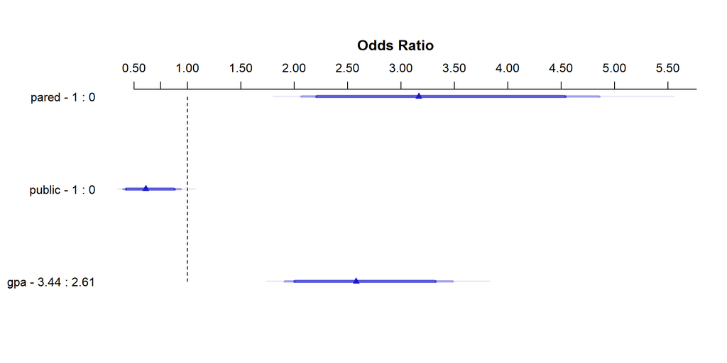

## Effects Summary

```r
summary(mod)
```

```
             Effects              Response : apply

 Factor      Low  High Diff. Effect   S.E.    Lower 0.95 Upper 0.95
 pared       0.00 1.00 1.00   1.15250 0.21843  0.72436    1.580600
  Odds Ratio 0.00 1.00 1.00   3.16600      NA  2.06340    4.857900
 public      0.00 1.00 1.00  -0.49486 0.21951 -0.92509   -0.064629
  Odds Ratio 0.00 1.00 1.00   0.60966      NA  0.39650    0.937410
 gpa         2.61 3.44 0.83   0.94756 0.15354  0.64662    1.248500
  Odds Ratio 2.61 3.44 0.83   2.57940      NA  1.90910    3.485100
```

### Coefficients in the `mod` equation

```r
mod$coef
```

```
y>=somewhat likely     y>=very likely              pared             public
         -3.872786          -5.941317           1.152479          -0.494859
               gpa
          1.141633
```

## Nomogram of `mod`

```r
fun.1 <- function(x) 1 - plogis(x)
fun.3 <- function(x)
    plogis(x - mod$coef[1] + mod$coef[2])

plot(nomogram(mod,
    fun=list('Prob Y = 1 (unlikely)' = fun.1,
             'Prob Y = 3 (very likely)' = fun.3)))
```

## Nomogram of `mod`

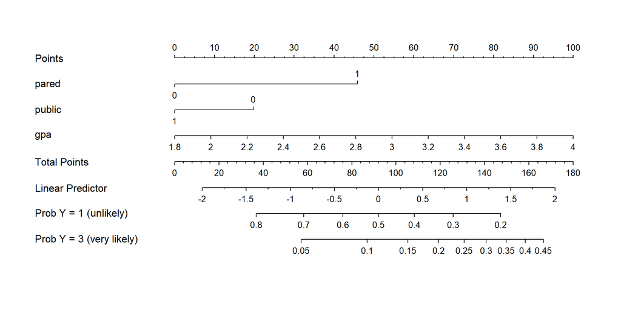

## Next Time (Class 18)

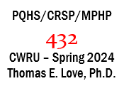

432 Class 17 | 2024-03-19 | https://thomaselove.github.io/432-2024/